# Neural Networks 2

16 04 2019

## Машинное обучение

Отрасль ИИ, которая помогает компьютерам программировать себя на основе входных данных.

Машинное обучение дает ИИ возможность решать проблемы на основе определенной входной информации.

Искусственные нейронные сети являются ярким представителем использования алгоритмов машинного обучения.

## Типы обучения

- Обучение с учителем (Supervised learning)
- Обучение без учителя (Unsupervised learning)
- Обучение с подкреплением (Reinforcement learning)

## Действие искусственных нейронов

\[ y=b+\sum xw_{i} \] b - смещение

w - вес i-ого нейрона

x - значения нейрона

## Forward propagation. Прямое распространение

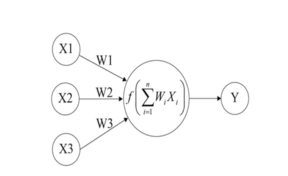

## Функции активации

- Линейная функция нейрона
- Функция бинарной активации нейрона
- Rectified Linear Unit - ReLU
- Сигмоидная функция активации
- Гиперболический тангенс

## Линейная функция нейрона

Линеная функция нейрона - аналог регрессионной модели.

\[ y=b+\sum xw_{i} \]

## Функция бинарной активации нейрона

\[ z=b+\sum xw_{i} \]

\[ y = \begin{cases} & \text{1 if z >= 0} \\ & \text{0 if z < 0 } \end{cases} \]

## Бином

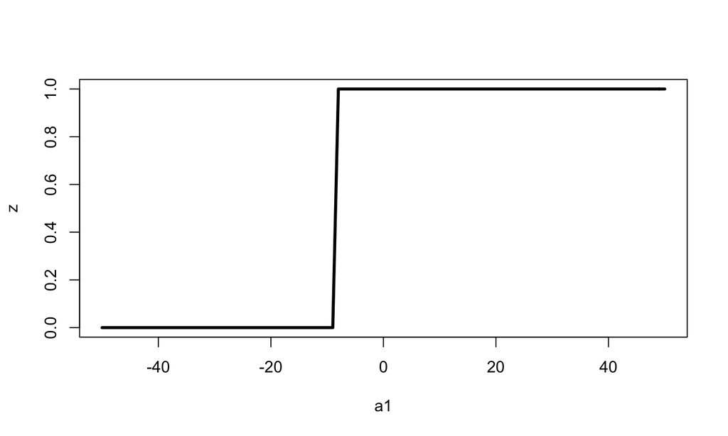

## Rectified Linear Unit - ReLU

Функция активации, которая очищает ряд значений от отрицательных, а для положительных принимает линйные значения называется Rectified Linear Unit - ReLU

\[ z=b+\sum xw_{i} \]

\[ y = \begin{cases} & \text{z if z > 0} \\ & \text{0 if z <= 0 } \end{cases} \]

## ReLU

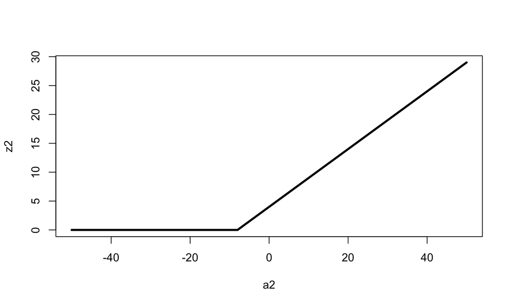

## Сигмоидная функция активации

Сигмоидная функция - это математическая функция, которая строит сигмоидальную кривую; Это самая ранняя и часто используемая функция активации вместе с ReLU. Данная функция сводит входные данные к любому значению от 0 до 1 и делает модель логистической по своей природе.

\[ z=b+\sum xw_{i} \]

\[ y = \frac{1}{1+e^{-z}} \]

## Sigmoid

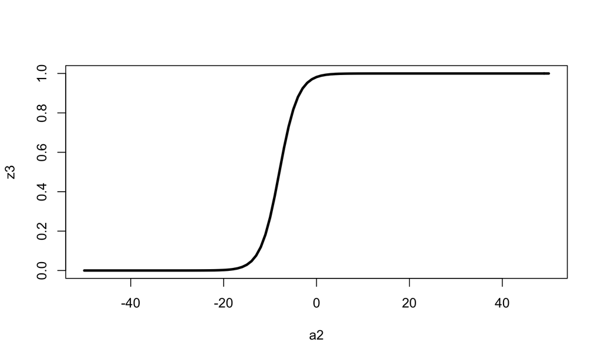

## Гиперболический тангенс

Функцию тангенса можно также представить как масштабированную сигмоидную функцию. Это нелинейная функция, определенная в диапазоне значений (-1, 1).

\[ z=b+\sum xw_{i} \]

\[ \text{th}z=\frac{\text{sh}z}{\text{ch}z} = \frac{e^{z} - e^{-z}}{e^{z} + e^{-z}} \]

## Tanh

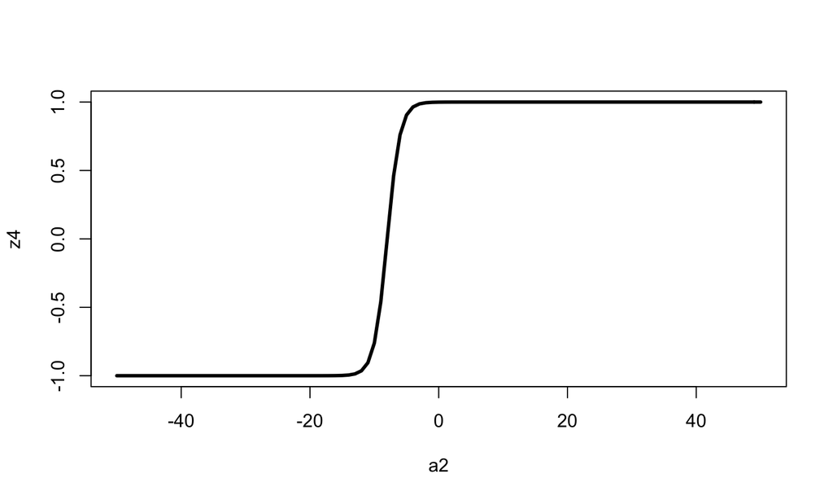

## Нормализация/шкалирование исходных данных

Масштабирование или нормализация данных - это процесс преобразования исходных данных в стандартизированном масштабе, чтобы обучение было улучшенным, точным и быстрым.

Метод масштабирования данных в нейронных сетях аналогичен нормализации данных в любой задаче машинного обучения.

## Нормализация Z-score

\[ z = \frac{x-\bar{x}}{\delta} \]

Здесь

x - значение элемента данных,

\(\bar{x}\) - среднее значение,

\(\delta\) - стандартное отклонение.

## Нормализация min-max

\[ z = \frac{x_{i} - min(x)}{max(x) - min(x)} \]

Здесь \(x_{i}\) - элемент данных,

\(min(x)\) - минимум значений \(x\) ,

\(max(x)\) - максимум всех значений данных \(x\).

## Медианная нормализация

\[ z = \frac{x_{i} - median(X)}{MAD(X)} \] Где

\(x_{i}\) - элемент данных,

\(median(x)\) - медиана значений \(x\) ,

\(MAD(x)\) - медианное абсолютное отклонение \(x\).

## Общий алгоритм действия нейронной сети

1. Прямое распространение ошибки

1.1 Берем входные и выходные данные

1.2 Мы инициализируем веса и смещения со случайными значениями (это однократное инициирование. На следующей итерации мы будем использовать обновленные веса и смещения)

1.3 Линейное преобразование (Мы берем матричное произведение входных данных и весов, затем добавляем смещения нейронов скрытого слоя к соответствующим входным данным)

1.4 Проводим нелинейную трансформацию с помощью активационной функции

1.5 Выполнияем линейное преобразование при активации скрытого слоя (берем матрицу с весами и добавляем смещение нейрона выходного слоя), затем применяем функцию активации

## 2. Обратное распространение ошибки

2.1 Сравнить прогнозное значение с фактическим и рассчитать градиент ошибки (Actual - Predicted). Ошибка - MSE = ((Y-t)^2)/2

2.2 Вычислить наклон/градиент нейронов скрытого и выходного слоев (чтобы вычислить наклон, мы вычисляем производные нелинейных активаций x на каждом слое для каждого нейрона). Градиент сигмоидной формы может быть возвращен как x * (1 - x).

2.3 Вычислить коэффициент изменения(дельта) в выходном слое в зависимости от градиента ошибки, умноженного на наклон активации выходного слоя

2.4 На следующем этапе ошибка будет распространяться обратно в сеть, что определяет ошибку на скрытом уровне. Для этого необходимо посчитать скалярное произведение дельты выходного слоя с весовыми параметрами граней между скрытым и выходным слоями.

2.5 Вычислить коэффициент изменения (дельта) на скрытом слое, умножить ошибку скрытого слоя на наклон активации скрытого слоя

2.6 Обновить веса на выходном и скрытом слое. Веса в сети могут быть обновлены на основе ошибок, рассчитанных для тренировочных примеров.

2.7 Обновить смещения на выходном и скрытом слое. Смещения в сети могут быть обновлены на основе агрегированных ошибок нейрона.

## Коэффициент скорости обучения (Learning rate)

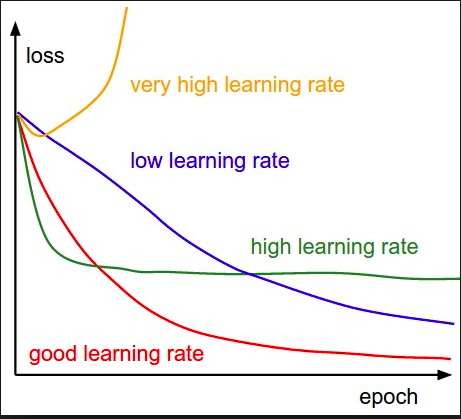

## Коэффициент скорости обучения

Остаточная ошибка = 350 «Дельта-правило» для обучения:

\(Δwi = ε*xi*(t - y)\)

При скорости обучения \(ε = 1/35\) изменения веса +20, +50, +30 Это дает новые веса 70, 100, 80.